# Criação de gráficos com o ggplot2

GGplot2

Graficos

R

Autores

Ana Li

Gabriel Gonçalves

**Orientador:** Rafael Erbisti

# **Introdução ao ggplot2**

[figure not shown]

O `ggplot2` é um pacote estruturado de forma que seja possível criar gráficos elaborados a partir de múltiplas camadas. Os componentes básicos são os mesmos para todos os gráficos: um conjunto de dados, sistema de coordenadas e os objetos geométricos denominados `geoms`.

Para construir os gráficos, é utilizada a função `ggplot( )`. Após definir seus argumentos principais, outras funções são usadas em cadeia (formando camadas) , com o sinal *+*, para customizar o painel da maneira que o usuário preferir.

# **Gráfico de pontos**

## **Definindo os principais elementos**

A base utilizada para exemplificar as funções será a do arquivo `student_habits_performance.csv`.

```r
# Instalando e carregando o pacote
if (!require("ggplot2")) install.packages("ggplot2")
library(ggplot2)

# Leitura da base de dados
library(tidyverse)
performance = read_csv("base/student_habits_performance.csv")
# Retirando o gênero 'Other'
performance = performance %>%
    filter(gender != "Other")

performance
```

```
# A tibble: 958 × 16
   student_id   age gender study_hours_per_day social_media_hours netflix_hours
   <chr>      <dbl> <chr>                <dbl>              <dbl>         <dbl>
 1 S1000         23 Female                 0                  1.2           1.1
 2 S1001         20 Female                 6.9                2.8           2.3
 3 S1002         21 Male                   1.4                3.1           1.3
 4 S1003         23 Female                 1                  3.9           1
 5 S1004         19 Female                 5                  4.4           0.5
 6 S1005         24 Male                   7.2                1.3           0
 7 S1006         21 Female                 5.6                1.5           1.4
 8 S1007         21 Female                 4.3                1             2
 9 S1008         23 Female                 4.4                2.2           1.7
10 S1009         18 Female                 4.8                3.1           1.3
# ℹ 948 more rows
# ℹ 10 more variables: part_time_job <chr>, attendance_percentage <dbl>,
#   sleep_hours <dbl>, diet_quality <chr>, exercise_frequency <dbl>,
#   parental_education_level <chr>, internet_quality <chr>,
#   mental_health_rating <dbl>, extracurricular_participation <chr>,
#   exam_score <dbl>
```

O primeiro argumento da função `ggplot( )` é o *data*, o data.frame com os dados. Em seguida, precisamos mapear as propriedades visuais do gráfico com o *mapping*, utilizando o *aes*. No argumento *aes*, devem ser especificadas as variáveis dos eixos *x* e *y*, *cores* e *símbolos* para plotar os dados.

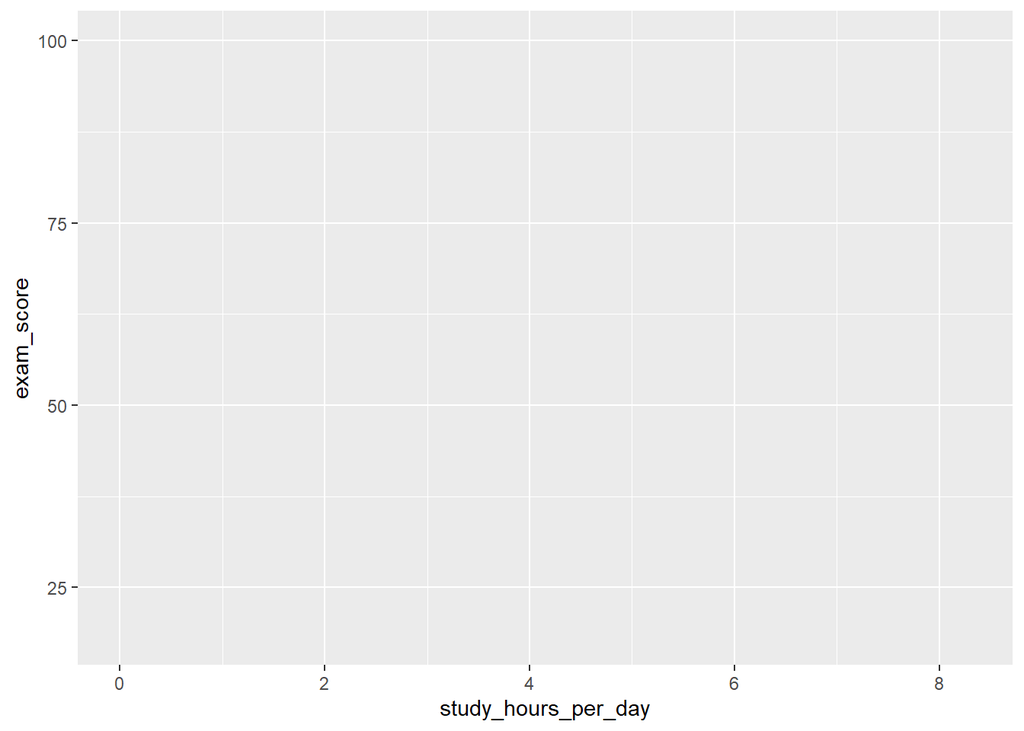

```r
performance %>%
    ggplot(mapping = aes(x = study_hours_per_day, y = exam_score))
```

Percebam que o gráfico está vazio. Precisamos adicionar a camada com o elemento `geom_`. Neste caso, como queremos um gráfico de dispersão, vamos utilizar o `geom_point( )`

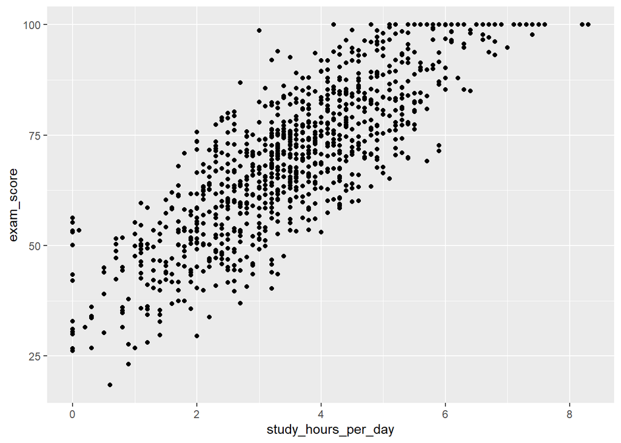

```r
performance %>%
    ggplot(aes(x = study_hours_per_day, y = exam_score)) + geom_point()
```

Pode-se definir outras especificações em uma função `geom_`. No gráfico abaixo, foram modificados o tamanho, o formato, a cor e a transparência (que varia de 0 a 1) dos pontos.

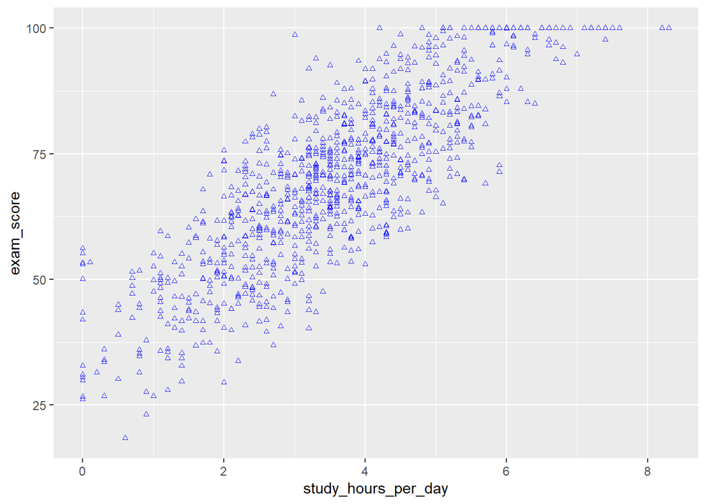

```r
performance %>%
    ggplot(aes(x = study_hours_per_day, y = exam_score)) + geom_point(size = 1, color = "blue",
    shape = 24, alpha = 0.8)
```

É possível também, adicionar outros elementos geométricos no mesmo gráfico. Neste exemplo, foi adicionada uma reta de regressão linear pela função `geom_smooth`

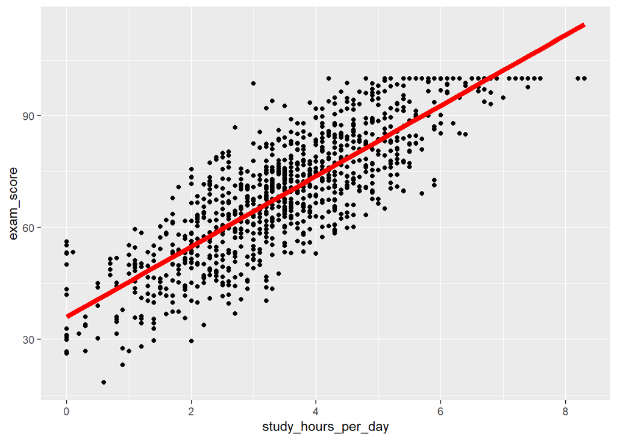

```r
performance %>%
  ggplot(aes(x = study_hours_per_day, y = exam_score)) +
  geom_point() +
  geom_smooth(method='lm', # o método utilizado é o linear model
              se = F, # retirando o se (erro padrão)
              linewidth=2, # alterando a grossura da linha
              color='red')
```

## **Agrupamentos**

Além de mapear as variáveis que devem aparecer nos eixos, também se pode usar variáveis para mapear cores, forma, tamanho, transparência e outras características visuais dos objetos geométricos no gráfico. Isso permite sobrepor grupos de observações em um mesmo gráfico.

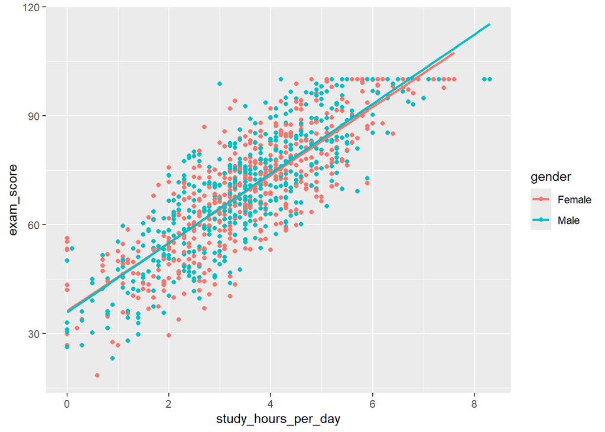

```r
# Mapando as cores dos pontos de acordo com o gênero
performance %>%
    ggplot(aes(x = study_hours_per_day, y = exam_score, color = gender)) + geom_point() +
    geom_smooth(method = "lm", se = F)
```

## **Escalas**

o `ggplot2` fornece escalas automáticas aos gráficos. No entanto, o controle sobre essas escalas é necessário para uma melhor visualização.

As funções utilizadas para controlar as escalas dos elementos de um gráfico do ggplot2 seguem um padrão. Todas possuem nomes iniciados com `scale_`, depois o nome do elemento estético (color, fill, x etc.) e, por fim, o tipo/nome da escala que será aplicada.

As especificações do `scale_x_continuous` e do `scale_y_continuous` incluem o breaks e label.

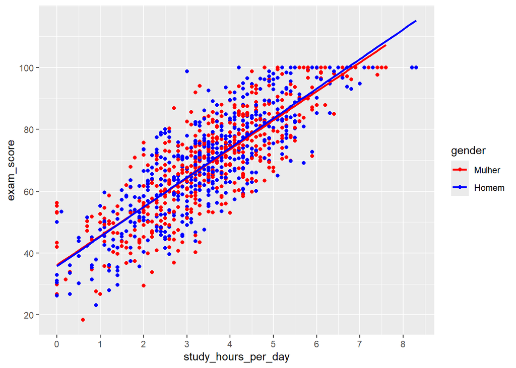

```r
performance %>%
  ggplot(aes(x = study_hours_per_day, y = exam_score, color = gender)) +
  geom_point()+
  geom_smooth(method='lm',se = F)+
  scale_y_continuous(breaks = seq(0, 100, 20))+ # sequência de 0 a 100 a cada 20 unidades
  scale_x_continuous(breaks = seq(0,max(performance$study_hours_per_day,1)))+ #sequência de 0 ao máximo de horas de estudo a cada 1 unidade
  scale_color_manual(values = c("Red","Blue"), #atribuindo cores vermelho e azul
                     labels = c("Mulher","Homem")) #mudando o texto das categorias
```

## **Rótulos**

A função `labs` fornece rótulos personalizados para os eixos e legendas. Além disso, podem ser adicionados um título, subtítulo e legenda.

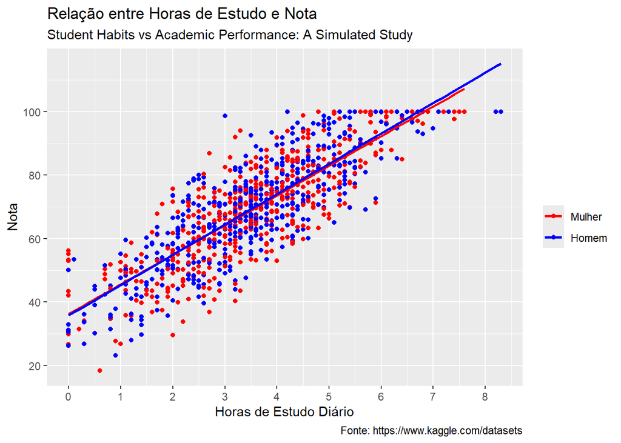

```r
performance %>%
  ggplot(aes(x = study_hours_per_day, y = exam_score, color = gender)) +
  geom_point()+
  geom_smooth(method='lm',se = F)+
  scale_y_continuous(breaks = seq(0, 100, 20))+
  scale_x_continuous(breaks = seq(0,max(performance$study_hours_per_day,1)))+
  scale_color_manual(values = c("Red","Blue"),
                     labels = c("Mulher","Homem")) +
  labs(x = "Horas de Estudo Diário",
       y = "Nota" ,
       color = "" , # foi deixado vazio dentro das aspas para tirar o o título da legenda
       title = "Relação entre Horas de Estudo e Nota",
       subtitle = "Student Habits vs Academic Performance: A Simulated Study",
       caption = "Fonte: https://www.kaggle.com/datasets")
```

## **Temas**

É possível alterar a aparência do gráfico manualmente usando o `theme( )` ou utilizando temas prontos com funções `theme_`.

No link `https://ggplot2.tidyverse.org/reference/ggtheme.html` são apresentados os tipos de temas prontos do pacote.

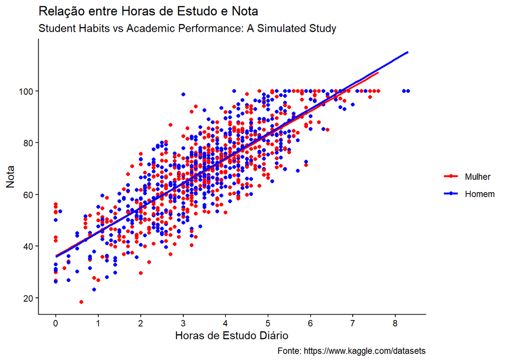

```r
# Usando o theme_classic( )
performance %>%
  ggplot(aes(x = study_hours_per_day, y = exam_score, color = gender)) +
  geom_point()+
  geom_smooth(method='lm',se = F)+
  scale_y_continuous(breaks = seq(0, 100, 20))+
  scale_x_continuous(breaks = seq(0,max(performance$study_hours_per_day,1)))+
  scale_color_manual(values = c("Red","Blue"),
                     labels = c("Mulher","Homem"))+ # mudando o nome das categorias
  labs(x = "Horas de Estudo Diário", y = "Nota" ,color = "" ,
       title = "Relação entre Horas de Estudo e Nota",
       subtitle = "Student Habits vs Academic Performance: A Simulated Study",
       caption = "Fonte: https://www.kaggle.com/datasets") +
  theme_classic()
```

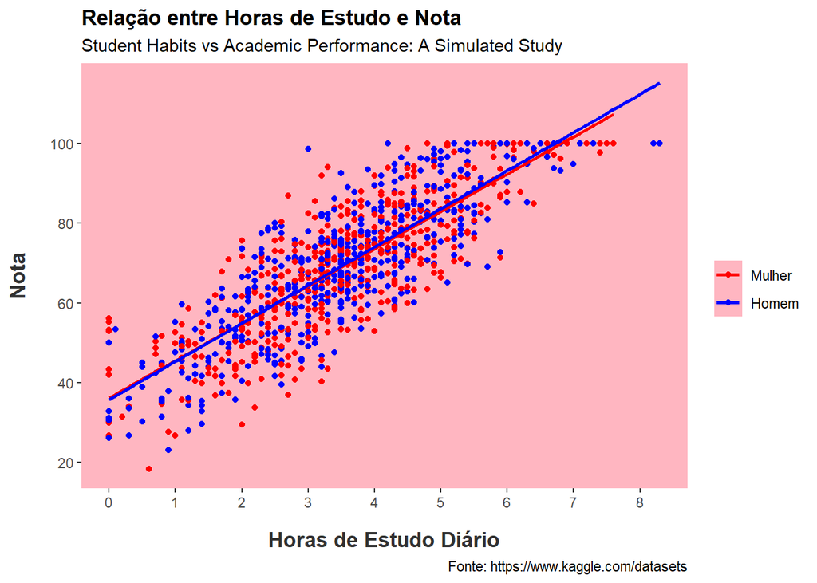

```r
#Modificando o tema manualmente
performance %>%
  ggplot(aes(x = study_hours_per_day, y = exam_score, color = gender)) +
  geom_point()+
  geom_smooth(method='lm',se = F)+
  scale_y_continuous(breaks = seq(0, 100, 20))+
  scale_x_continuous(breaks = seq(0,max(performance$study_hours_per_day,1)))+
  scale_color_manual(values = c("Red","Blue"),
                     labels = c("Mulher","Homem"))+ # mudando o nome das categorias
  labs(x = "Horas de Estudo Diário",
       y = "Nota" ,
       color = "" , # tirando o rótulo
       title = "Relação entre Horas de Estudo e Nota",
       subtitle = "Student Habits vs Academic Performance: A Simulated Study",
       caption = "Fonte: https://www.kaggle.com/datasets") +
  theme(axis.title = element_text(size = 13, face = 'bold',color = "gray19"), # colocando o título dos eixos em negrito e mudando a cor
        axis.title.x = element_text(margin = margin(t = 13)), # aumentando a margem entre o rótulo do eixo x e o gráfico
        axis.title.y = element_text(margin = margin(r = 13)), # aumentando a margem entre o rótulo do eixo y e o gráfico
        plot.title = element_text(face = 'bold'), # deixando o título do gráfico em negrito
        panel.grid = element_blank(), # retirando a borda do gráfico
        panel.background = element_rect(fill = 'lightpink')) # mudando a cor do fundo
```

As cores podem ser definidas pelo nome padrão do R ou em código hexadecimal.

Cores padrão do R -> `http://www.stat.columbia.edu/~tzheng/files/Rcolor.pdf`

Cores em código hexadecimal -> Gerador de cores aleatórias `https://coolors.co/`

## **Facetas**

Os `facets` reproduzem um gráfico para cada nível de uma determinada variável (ou combinação de variáveis). Os `facets` são criados usando funções que começam com `facet_`. Quando deseja-se criar gráficos para todas as categorias de uma variável categórica, pode-se usar o `facet_wrap`.

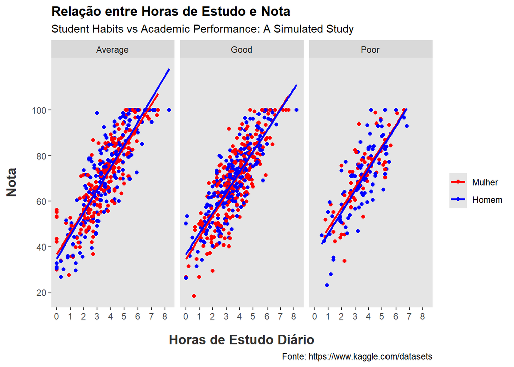

```r
performance %>%
  ggplot(aes(x = study_hours_per_day, y = exam_score, color = gender)) +
  geom_point()+
  geom_smooth(method='lm',se = F)+
  scale_y_continuous(breaks = seq(0, 100, 20))+
  scale_x_continuous(breaks = seq(0,max(performance$study_hours_per_day,1)))+
  scale_color_manual(values = c("Red","Blue"),
                     labels = c("Mulher","Homem"))+
  facet_wrap(~internet_quality)+ # reprodução do gráfico para categorias da variável qualidade de internet
  labs(x = "Horas de Estudo Diário", y = "Nota" ,color = "" ,
       title = "Relação entre Horas de Estudo e Nota",
       subtitle = "Student Habits vs Academic Performance: A Simulated Study",
       caption = "Fonte: https://www.kaggle.com/datasets") +
  theme(axis.title = element_text(size = 13, face = 'bold',color = "gray19"),
        axis.title.x = element_text(margin = margin(t = 13)),
        axis.title.y = element_text(margin = margin(r = 13)),
        plot.title = element_text(face = 'bold'),
        panel.grid = element_blank(),
        panel.background = element_rect(fill = 'gray90'))
```

Quando o interesse for em reproduzir os gráficos para os níveis de duas variáveis categóricas, a função `facet_grid( )` é utilizada.

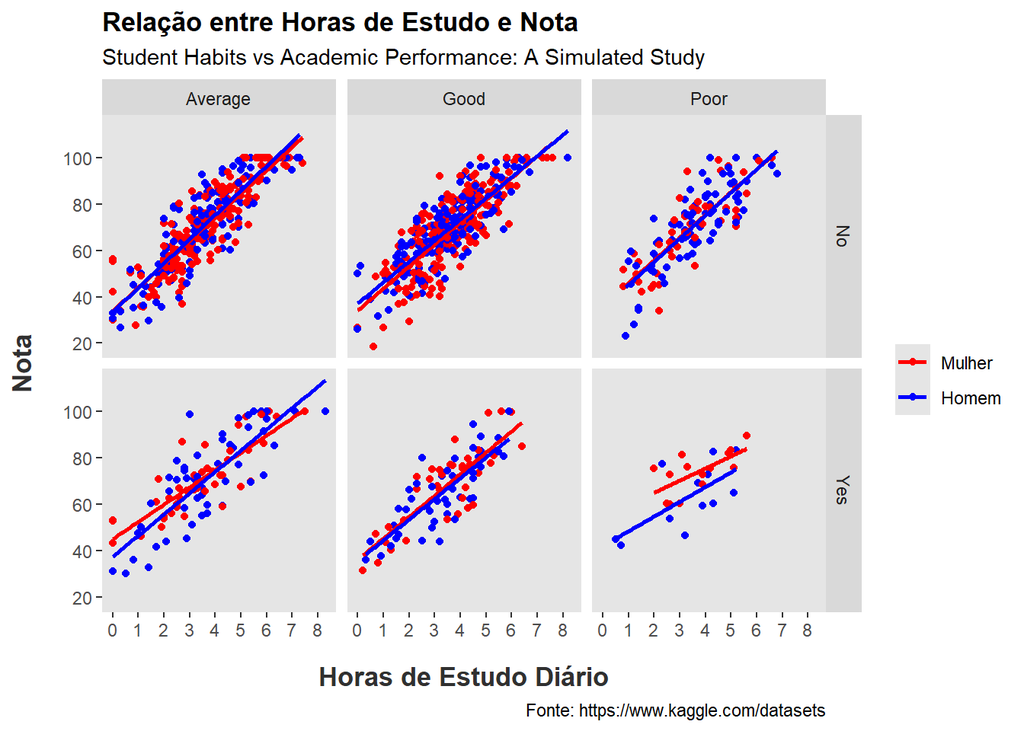

```r
performance %>%
  ggplot(aes(x = study_hours_per_day, y = exam_score, color = gender)) +
  geom_point()+
  geom_smooth(method='lm',se = F)+
  scale_y_continuous(breaks = seq(0, 100, 20))+
  scale_x_continuous(breaks = seq(0,max(performance$study_hours_per_day,1)))+
  scale_color_manual(values = c("Red","Blue"),
                     labels = c("Mulher","Homem"))+
  facet_grid(part_time_job~internet_quality)+ # reprodução do gráfico para qualidade da internet e trabalho
  labs(x = "Horas de Estudo Diário", y = "Nota" ,color = "" ,
       title = "Relação entre Horas de Estudo e Nota",
       subtitle = "Student Habits vs Academic Performance: A Simulated Study",
       caption = "Fonte: https://www.kaggle.com/datasets") +
  theme(axis.title = element_text(size = 13, face = 'bold',color = "gray19"),
        axis.title.x = element_text(margin = margin(t = 13)),
        axis.title.y = element_text(margin = margin(r = 13)),
        plot.title = element_text(face = 'bold'),
        panel.grid = element_blank(),
        panel.background = element_rect(fill = 'gray90'))
```

É possível alterar o texto das categorias dos `facets` com o argumento `labeller` ou modificando direto na base.

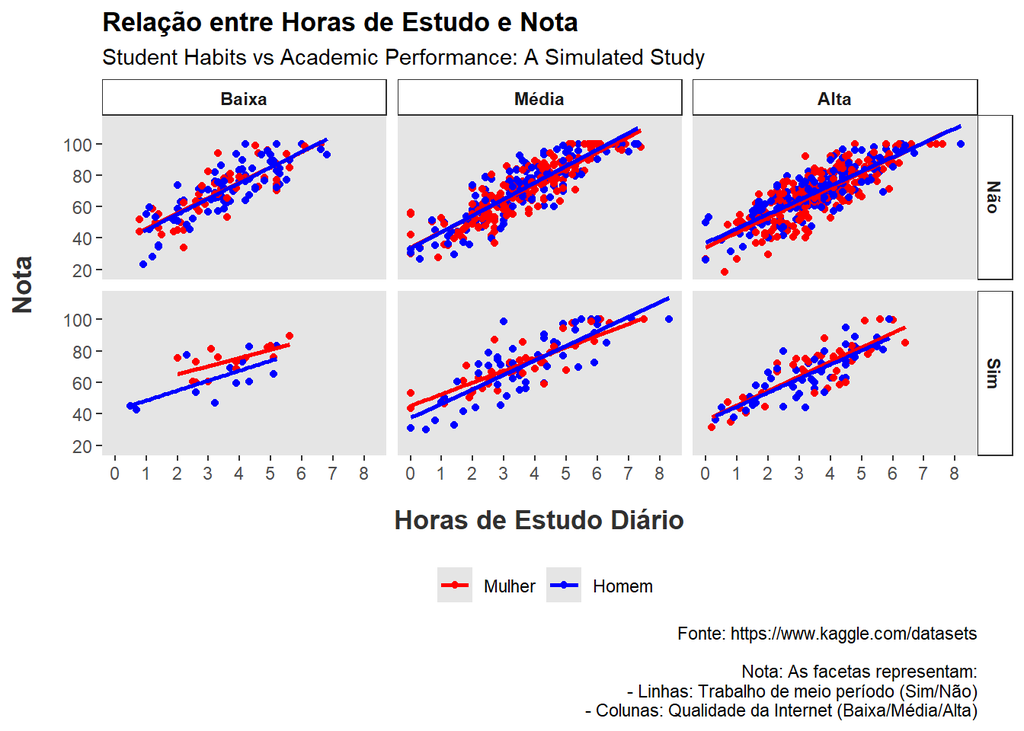

```r
# base modificada
perf_final = performance%>% mutate(internet_quality = factor(internet_quality,
                                      levels = c('Poor','Average','Good'),
                                      labels = c('Baixa','Média','Alta')))

# vetor com novos rótulos
job = c('Yes'='Sim','No'='Não')

perf_final %>%
  ggplot(aes(x = study_hours_per_day, y = exam_score, color = gender)) +
  geom_point()+
  geom_smooth(method='lm',se = F)+
  scale_y_continuous(breaks = seq(0, 100, 20))+
  scale_x_continuous(breaks = seq(0,max(performance$study_hours_per_day,1)))+
  scale_color_manual(values = c("Red","Blue"),
                     labels = c("Mulher","Homem"))+ # mudando o nome das categorias
  facet_grid(part_time_job~internet_quality,
             labeller = labeller(part_time_job = job))+ # reprodução do gráfico para qualidade da internet e trabalho e mudanças nos textos das categorias
  labs(x = "Horas de Estudo Diário", y = "Nota" ,color = "" ,
       title = "Relação entre Horas de Estudo e Nota",
       subtitle = "Student Habits vs Academic Performance: A Simulated Study",
       caption = "Fonte: https://www.kaggle.com/datasets\n\nNota: As facetas representam:\n- Linhas: Trabalho de meio período (Sim/Não)\n- Colunas: Qualidade da Internet (Baixa/Média/Alta)") +
  theme(axis.title = element_text(size = 13, face = 'bold',color = "gray19"),
        axis.title.x = element_text(margin = margin(t = 13)),
        axis.title.y = element_text(margin = margin(r = 13)),
        plot.title = element_text(face = 'bold'),
        panel.grid = element_blank(),
        panel.background = element_rect(fill = 'gray90'),
        strip.background = element_rect(fill='white',color='gray19'),
        strip.text = element_text(face='bold'), # deixando o texto das categorias em negrito
        legend.position = 'bottom') # alterando a posição da legenda
```

## **Gráfico de médias com intervalos de erro**

O gráfico de médias com intervalos de erro é um método popular para comparar grupos com relação a uma variável numérica . A barra de erro pode representar um desvio padrão, um erro padrão da média ou um intervalo de confiança.

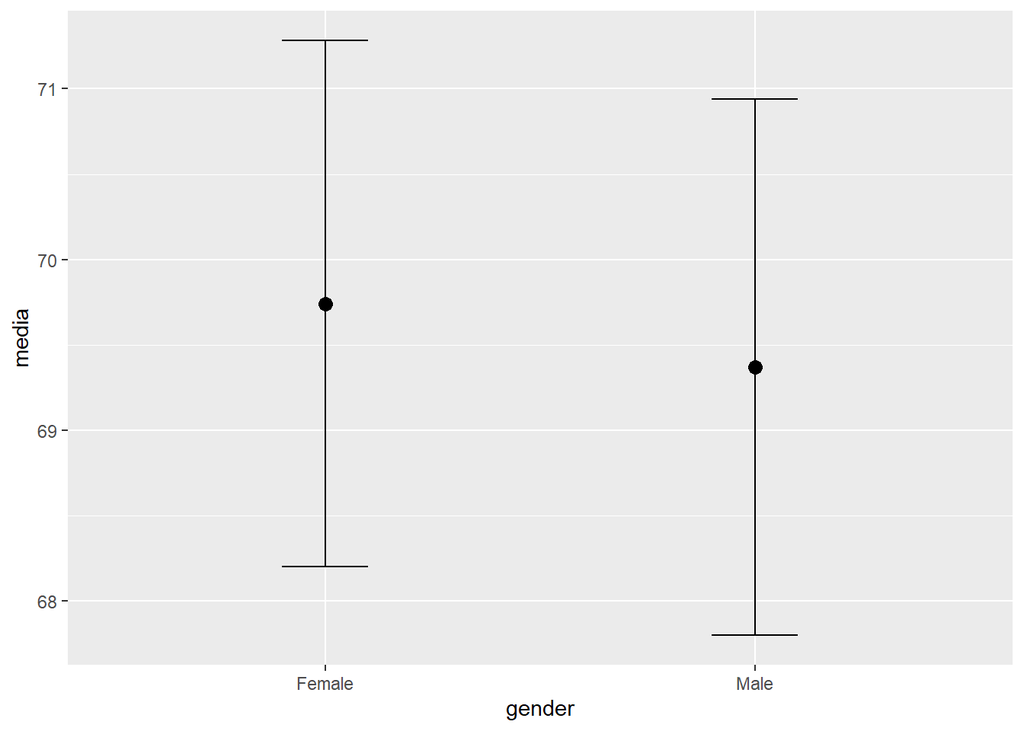

```r
media_perf = performance %>%
  group_by(gender) %>%
  summarise(n = n(),
            media = mean(exam_score, na.rm=TRUE),
            dp = sd(exam_score, na.rm = TRUE),
            errop = dp/sqrt(n))

media_perf %>%
  ggplot(aes(x = gender,y = media))+
  geom_point(size =3)+
  geom_errorbar(aes(ymin = media - 2*errop, # definindo o limite mínimo do eixo y
                    ymax = media + 2*errop),# definindo o limite máximo do eixo y
                width=0.2) # definindo o tamanho do traço
```

Podemos comparar a média entre mais grupos.

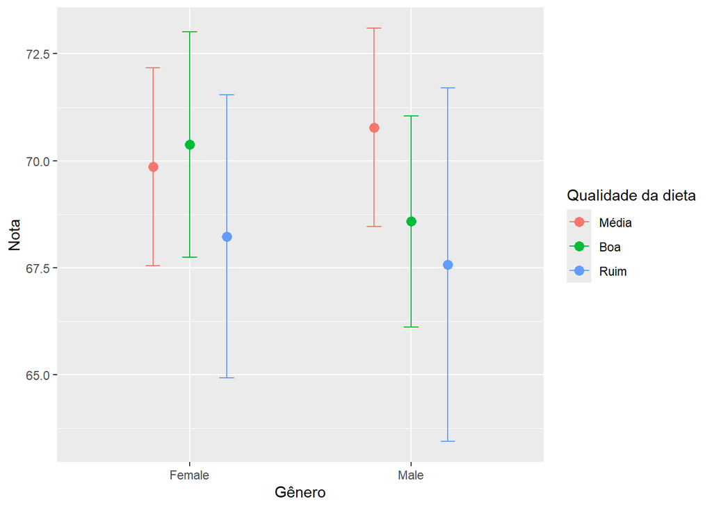

```r
media_perf = performance %>%
  group_by(gender,diet_quality) %>%
  summarise(n = n(),
            media = mean(exam_score, na.rm=TRUE),
            dp = sd(exam_score, na.rm = TRUE),
            errop = dp/sqrt(n))

media_perf %>%
  ggplot(aes(x = gender, y = media, color=diet_quality))+
  geom_point(size =3,
             position = position_dodge(width = 0.5))+ # argumento para evitar sobreposição dos pontos
  geom_errorbar(aes(ymin = media - 2*errop,
                    ymax = media + 2*errop),
                width=0.2,
                position = position_dodge(width = 0.5)) + # argumento para evitar sobreposição das barras
  scale_color_discrete(labels = c('Média','Boa','Ruim'))+ # mmudando o texto das categorias
  labs(x = 'Gênero', y = 'Nota', color = 'Qualidade da dieta')
```

# **Gráfico de barras**

Outra base utilizada será a do arquivo `DENGBR23.csv`

```r
# Lendo os dados
dengue2023 = read_csv("base/DENGBR23.csv")

# Selecionando as colunas de interesse e modificando as categorias
dados = dengue2023 %>%
    select(3:ID_OCUPA_N) %>%
    mutate(DT_NOTIFIC = as.Date(DT_NOTIFIC), REGIAO = case_when(SG_UF %in% c(11,
        12, 13, 14, 15, 16, 17) ~ "Norte", SG_UF %in% c(21, 22, 23, 24, 25, 26, 27,
        28, 29) ~ "Nordeste", SG_UF %in% c(50, 51, 52, 53) ~ "Centro-Oeste", SG_UF %in%
        c(31, 32, 33, 35) ~ "Sudeste", SG_UF %in% c(41, 42, 43) ~ "Sul"), CS_RACA = factor(CS_RACA,
        levels = c(1, 2, 3, 4, 5, 9), labels = c("Branca", "Preta", "Amarela", "Parda",
            "Indígena", "Ignorado")))

dados
```

```
# A tibble: 1,508,653 × 22
   DT_NOTIFIC SEM_NOT NU_ANO SG_UF_NOT ID_MUNICIP ID_REGIONA ID_UNIDADE
   <date>       <dbl>  <dbl>     <dbl>      <dbl>      <dbl> <chr>
 1 2023-01-01  202301   2023        12     120070       1937 2000393
 2 2023-01-02  202301   2023        12     120005       1937 2001020
 3 2023-01-02  202301   2023        12     120005       1937 2001020
 4 2023-01-02  202301   2023        12     120030       1940 2000636
 5 2023-01-02  202301   2023        12     120005       1937 2001020
 6 2023-01-02  202301   2023        12     120030       1940 2000636
 7 2023-01-03  202301   2023        12     120035       1941 2002132
 8 2023-01-03  202301   2023        12     120039       1941 7554923
 9 2023-01-03  202301   2023        12     120035       1941 2002132
10 2023-01-03  202301   2023        12     120010       1937 2001500
# ℹ 1,508,643 more rows
# ℹ 15 more variables: DT_SIN_PRI <date>, SEM_PRI <dbl>, ANO_NASC <dbl>,
#   NU_IDADE_N <dbl>, CS_SEXO <chr>, CS_GESTANT <dbl>, CS_RACA <fct>,
#   CS_ESCOL_N <dbl>, SG_UF <dbl>, ID_MN_RESI <dbl>, ID_RG_RESI <dbl>,
#   ID_PAIS <dbl>, DT_INVEST <date>, ID_OCUPA_N <chr>, REGIAO <chr>
```

O gráfico de barras ou colunas é utilizado para fazer comparações entre as categorias de uma variável qualitativa.

No gráfico abaixo, é apresentando um gráfico de barras de frequência de casos de dengue por raça.

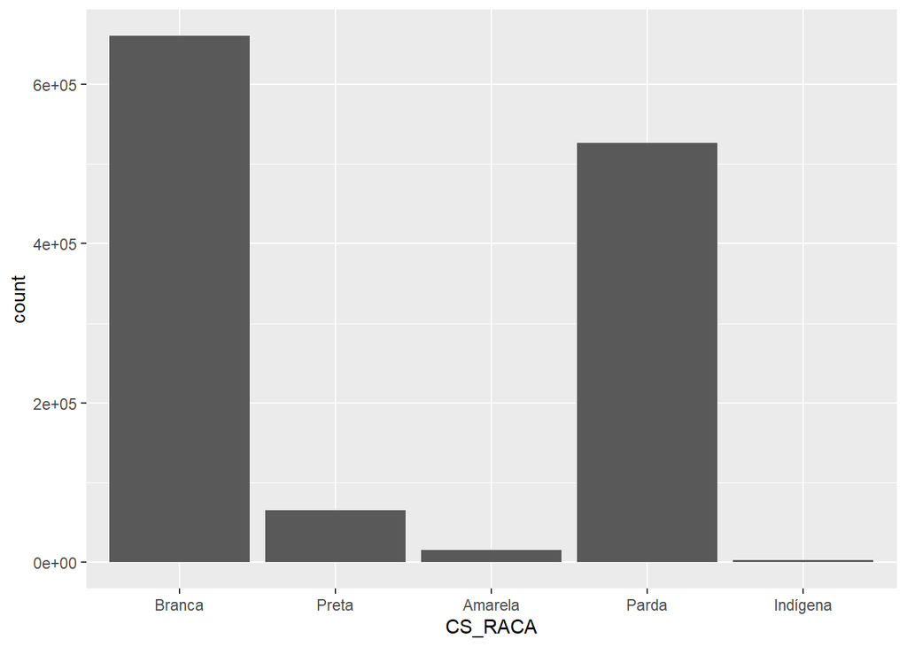

```r
dados %>%
    filter(!CS_RACA == "Ignorado", !is.na(CS_RACA)) %>%
    ggplot(aes(x = CS_RACA)) + geom_bar()  # por default, o geom_bar() adota o stat = 'count'
```

Outra forma de fazer o mesmo gráfico, é criando um `tibble` com uma coluna adicional com as frequências e utilizando-a para a construção do gráfico.

```r
# criando a tabela

casos_raca = dados %>%
    group_by(CS_RACA) %>%
    summarize(n = n())

casos_raca
```

```
# A tibble: 7 × 2
  CS_RACA       n
  <fct>     <int>
1 Branca   660516
2 Preta     65251
3 Amarela   15842
4 Parda    526535
5 Indígena   3027
6 Ignorado 237475
7 <NA>          7
```

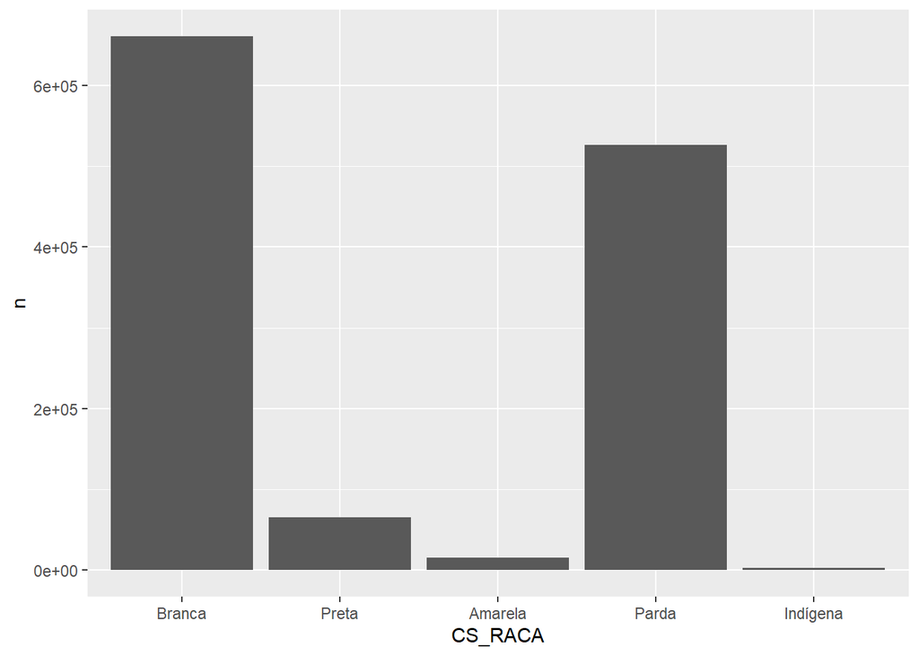

```r
# plotando

casos_raca %>%
    filter(!CS_RACA == "Ignorado", !is.na(CS_RACA)) %>%
    ggplot(aes(x = CS_RACA, y = n)) + geom_bar(stat = "identity")  # o 'identity' serve para indicar à função que as barras deverão ser plotadas de acordo com os valores do y
```

As barras podem ser customizadas dentro da função `geom_bar` com o `fill` e `color`. Esses argumentos controlam as cores do preenchimento e do contorno da barra, respectivamente. Também usa-se o labs para tratar os rótulos do gráfico.

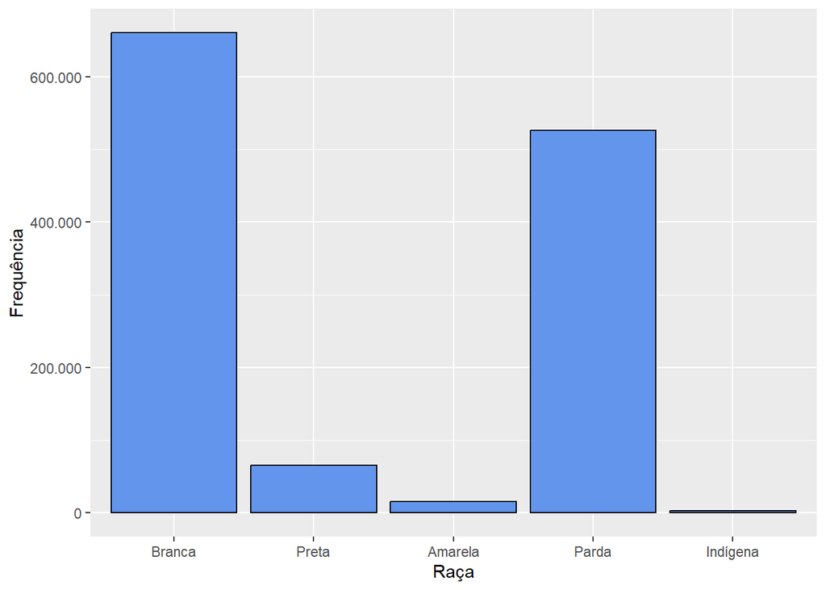

```r
casos_raca %>%
  filter(!CS_RACA == 'Ignorado',
         !is.na(CS_RACA)) %>%
  ggplot(aes(x = CS_RACA,y = n))+
  geom_bar(stat = 'identity',
           fill = 'cornflowerblue', # mudando a cor de preenchimento
           color='black')+ # mudando a cor do contorno
  scale_y_continuous(labels = scales::number_format(big.mark = '.',decimal.mark = ','))+ # tirando a notação científica
  labs(x = 'Raça', y = 'Frequência') # alterando os rótulos
```

As formas comuns de apresentar as barras, são em ordem crescente e decrescente.

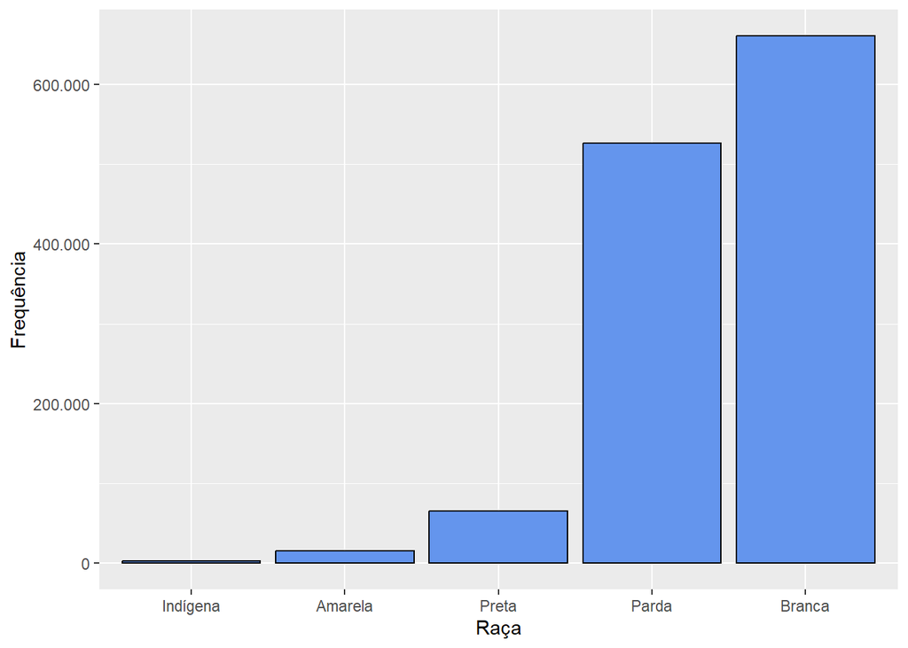

```r
# ordenando as barras

##crescente
casos_raca %>%
  filter(!CS_RACA == 'Ignorado',
         !is.na(CS_RACA))%>%
  ggplot(aes(x = reorder(CS_RACA,n),y = n))+ # reordenando de acordo com o valor de n (frequência)
  geom_bar(stat = 'identity',fill = 'cornflowerblue',color='black')+
  scale_y_continuous(labels = scales::number_format(big.mark = '.',decimal.mark = ','))+
  labs(x = 'Raça', y = 'Frequência')
```

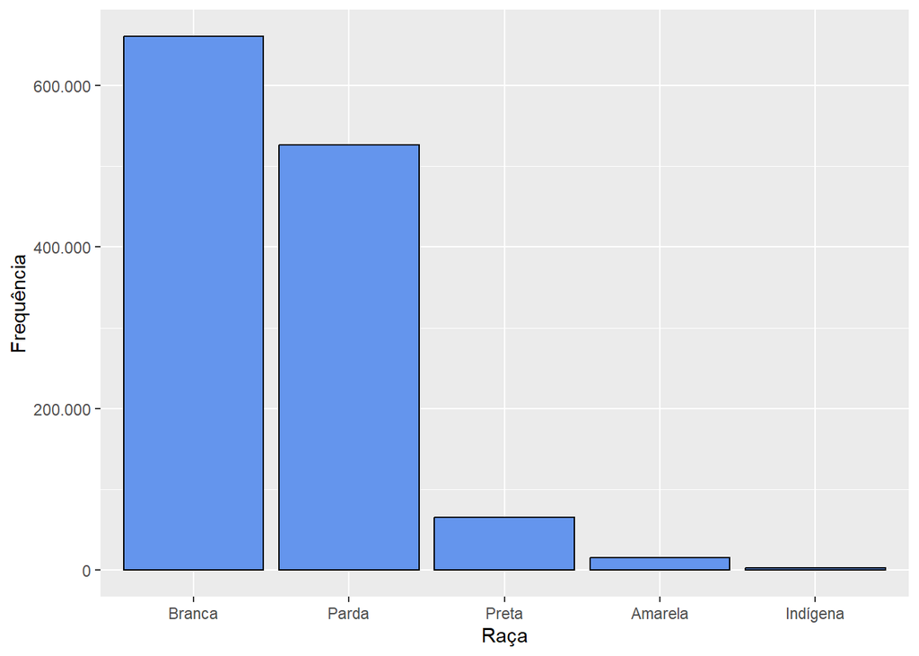

```r
##decrescente
casos_raca %>%
  filter(!CS_RACA == 'Ignorado',
         !is.na(CS_RACA)) %>%
  ggplot(aes(x = reorder(CS_RACA,-n),y = n))+ # reordenando de acordo com o valor de -n
  geom_bar(stat = 'identity',fill = 'cornflowerblue',color='black')+
  scale_y_continuous(labels = scales::number_format(big.mark = '.',decimal.mark = ','))+
  labs(x = 'Raça', y = 'Frequência')
```

Para incluir os valores observados nas barras, usa-se o `geom_text`, que é utilizado para incluir uma camada de texto. No mapeamento do `geom_text` foram incluídos como rótulos os valores `n` e o `vjust` para controlar o alinhamento vertical (hjust controla o alinha horizontal).

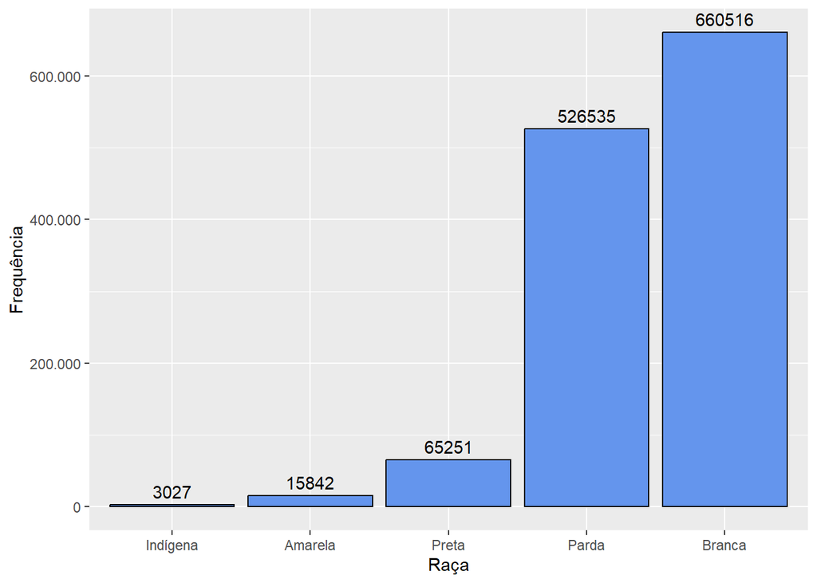

```r
casos_raca %>%
    filter(!CS_RACA == "Ignorado", !is.na(CS_RACA)) %>%
    ggplot(aes(x = reorder(CS_RACA, n), y = n)) + geom_bar(stat = "identity", fill = "cornflowerblue",
    color = "black") + geom_text(aes(label = n), vjust = -0.5) + scale_y_continuous(labels = scales::number_format(big.mark = ".",
    decimal.mark = ",")) + labs(x = "Raça", y = "Frequência")
```

Dependendo do tamanho dos rótulos dos eixos, é necessário fazer modificações nos textos para facilitar a visualização dos gráficos. Existem algumas formas para evitar a sobreposição dos rótulos:

- Alterando a angulação dos rótulos com `axis.text.x` dentro da função `theme( )`

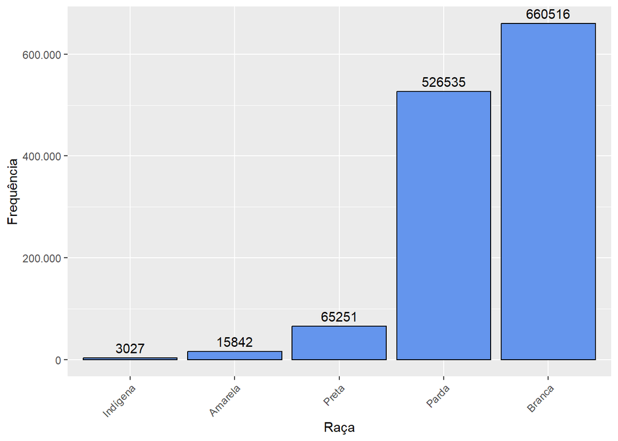

```r
casos_raca %>%
    filter(!CS_RACA == "Ignorado", !is.na(CS_RACA)) %>%
    ggplot(aes(x = reorder(CS_RACA, n), y = n)) + geom_bar(stat = "identity", fill = "cornflowerblue",
    color = "black") + geom_text(aes(label = n), vjust = -0.5) + scale_y_continuous(labels = scales::number_format(big.mark = ".",
    decimal.mark = ",")) + labs(x = "Raça", y = "Frequência") + theme(axis.text.x = element_text(angle = 45,
    hjust = 1))
```

- Escalonando os rótulos com o `scale_x_discrete` por meio do **guide**

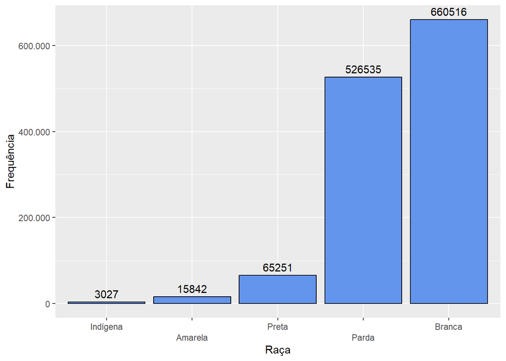

```r
casos_raca %>%
    filter(!CS_RACA == "Ignorado", !is.na(CS_RACA)) %>%
    ggplot(aes(x = reorder(CS_RACA, n), y = n)) + geom_bar(stat = "identity", fill = "cornflowerblue",
    color = "black") + geom_text(aes(label = n), vjust = -0.5) + scale_y_continuous(labels = scales::number_format(big.mark = ".",
    decimal.mark = ",")) + labs(x = "Raça", y = "Frequência") + scale_x_discrete(guide = guide_axis(n.dodge = 2))
```

- Invertendo o gráfico com o `coord_flip()`

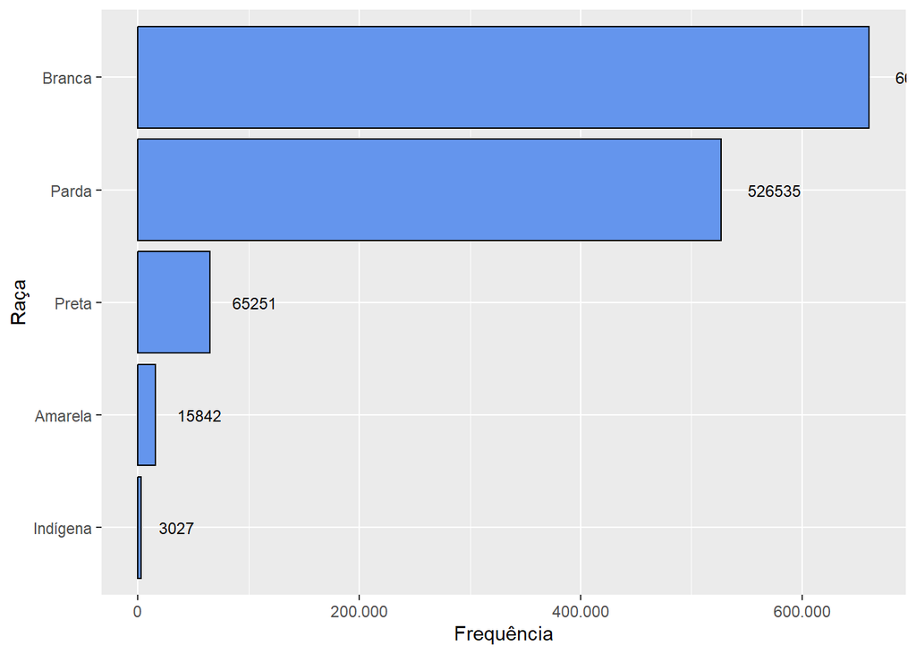

```r
casos_raca %>%
  filter(!CS_RACA == 'Ignorado',
         !is.na(CS_RACA))%>%
  ggplot(aes(x = reorder(CS_RACA,n),y = n))+
  geom_bar(stat = 'identity',fill = 'cornflowerblue',color='black')+
  geom_text(aes(label=n),
            hjust=-0.5, # como as coordenadas foram invertidas, o hjust é modificado
            size=3)+
  scale_y_continuous(labels = scales::number_format(big.mark = '.',decimal.mark = ','))+
  labs(x = 'Raça', y = 'Frequência')+
  coord_flip()
```

### **Gráfico Barras agrupadas**

O gráfico de barras agrupadas ajuda a avaliar a relação entre duas variáveis qualitativas.

O mapeamento do gráfico abaixo é definida pela raça (eixo x) e pelo sexo do indivíduo (fill). Desta forma, são construídas barras para cada raça com cores separadas de acordo com o sexo.

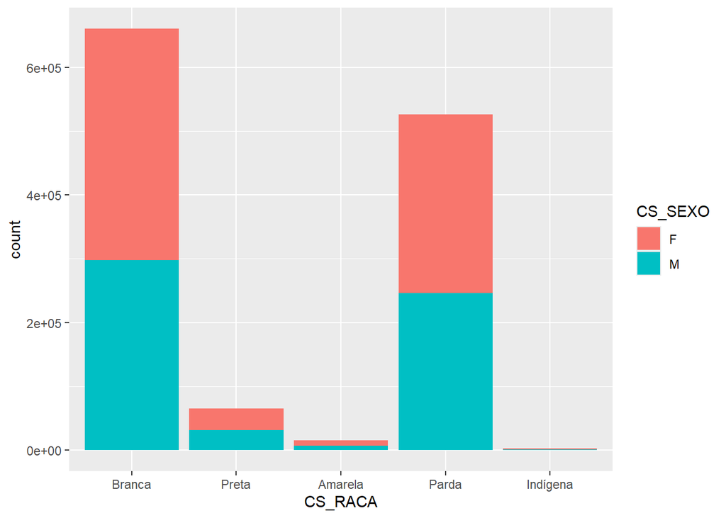

```r
dados %>%
    filter(!CS_RACA == "Ignorado", !is.na(CS_RACA), !CS_SEXO == "I") %>%
    ggplot(aes(x = CS_RACA, fill = CS_SEXO)) + geom_bar()  # por default, o geom_bar agrupado deixam as barras empilhadas (position ='stack')
```

Outra forma de apresentar essas informações é dispondo as barras lado a lado utilizando o argumento `position ='dodge'` dentro do `geom_bar( )`.

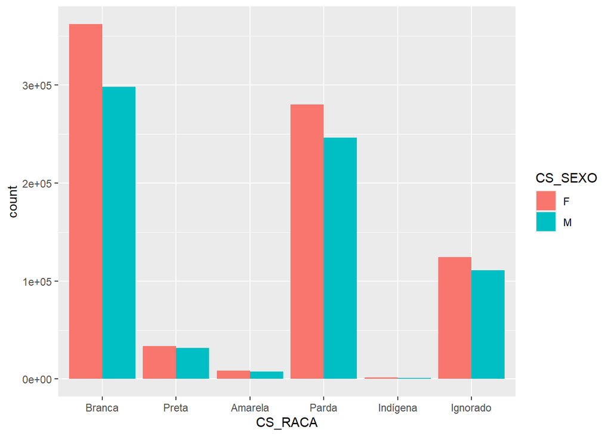

```r
dados %>%
    filter(!is.na(CS_RACA), !CS_SEXO == "I") %>%
    ggplot(aes(x = CS_RACA, fill = CS_SEXO)) + geom_bar(position = "dodge")
```

Para trabalhar com as barras empilhadas na escala de proporção é preciso inserir o argumento `position = 'fill'` dentro do `geom_bar()`.

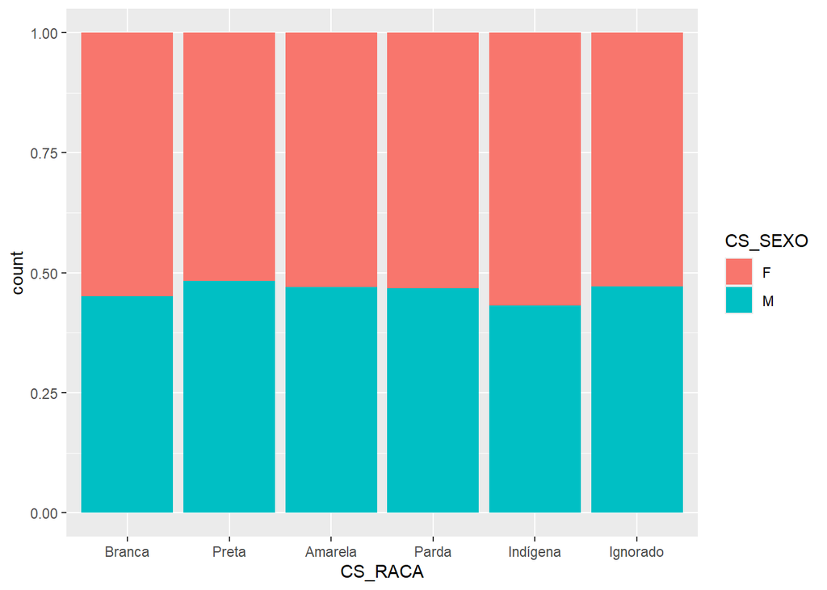

```r
dados %>%
    filter(!is.na(CS_RACA), !CS_SEXO == "I") %>%
    ggplot(aes(x = CS_RACA, fill = CS_SEXO)) + geom_bar(position = "fill")
```

É possível incluir os percentuais no gráfico, utilizando o `geom_text()`

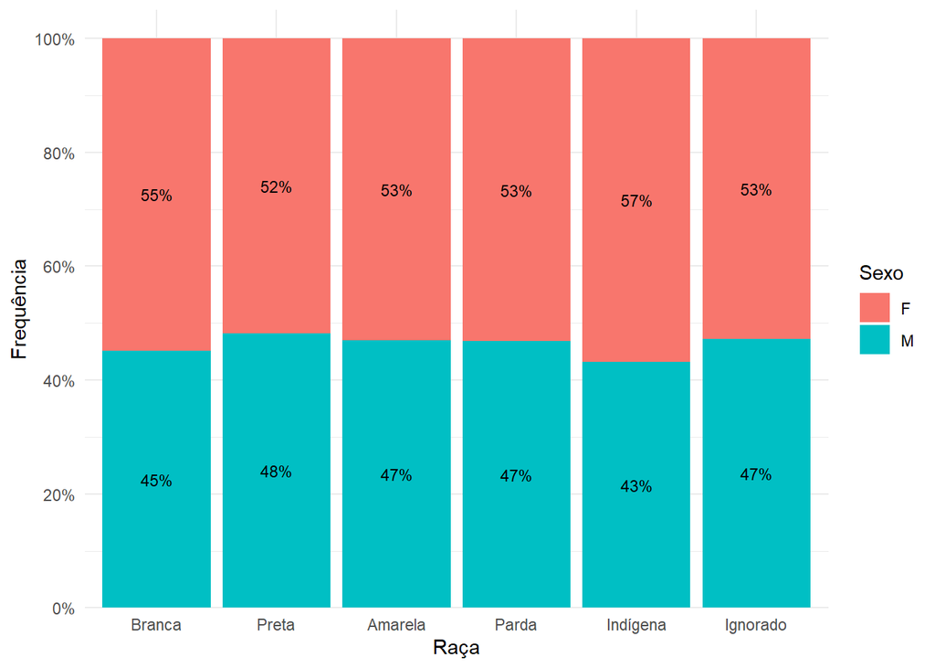

```r
#criando tabela com as contagens e proporções

casos_raca_genero = dados %>%
  filter(CS_SEXO %in% c('F','M'),
         !is.na(CS_RACA)) %>%
  group_by(CS_RACA,CS_SEXO) %>%
  summarise(n = n()) %>%
  mutate(prop = n/sum(n))

casos_raca_genero %>%  # Calcula posição central da barra
  ggplot(aes(x = CS_RACA, y = prop, fill = CS_SEXO)) + # mudando a ordem
  geom_bar(stat='identity',position = 'fill') +
  geom_text(aes(label = scales::percent(prop,accuracy = 1)), # colocando a proporção decimal como porcentagem sem casa decimal
            position = position_stack(vjust = 0.5), # definindo a posição do texto
            size=3)+
  scale_y_continuous(breaks = seq(0, 1, 0.2), # definindo as quebras do eixo
                     label = scales::percent, # definindo a escala em porcentagem
                     expand = expansion(add = c(0, 0.05))) + # grudando as barras no eixo
  labs(x = 'Raça', y = 'Frequência', fill = 'Sexo') +
  theme_minimal()
```

Para alterar as cores das barras de acordo com as categorias do `fill`, utilizamos a função `scale_fill_manual()` com os argumentos:

- `breaks` para definir a ordem as categorias na legenda
- `labels` para definir o nome das categorias na legenda
- `values` para definir a cor para cada categoria

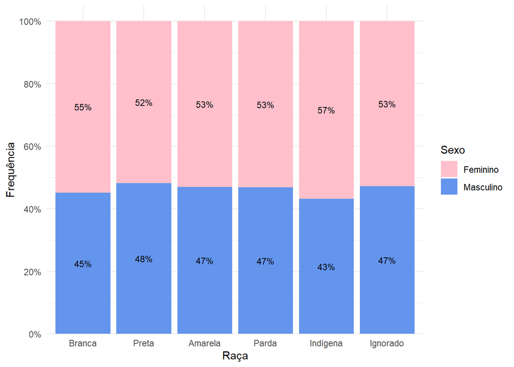

```r
casos_raca_genero %>%
    ggplot(aes(x = CS_RACA, y = prop, fill = CS_SEXO)) + geom_bar(stat = "identity",
    position = "fill") + geom_text(aes(label = scales::percent(prop, accuracy = 1)),
    position = position_stack(vjust = 0.5), size = 3) + scale_y_continuous(breaks = seq(0,
    1, 0.2), label = scales::percent, expand = expansion(add = c(0, 0.05))) + scale_fill_manual(breaks = c("F",
    "M"), labels = c("Feminino", "Masculino"), values = c("pink", "cornflowerblue")) +
    labs(x = "Raça", y = "Frequência", fill = "Sexo") + theme_minimal()
```